# Product Pricing and Purchase Behavior

Berkley Dixon

2023-02-25

## Introduction

When it comes to grocery stores, there are plenty of different ways to differentiate oneself. Big box stores sell mostly bulk products, while health food stores sell smaller, more expensive products. Most stores, such as Regork, stay somewhere in the middle. Are there certain places where Regork could change its approach to product sizing and pricing in order to better meet its customers’ needs and maximize profits? That’s our business question today: how does product sizing and pricing per unit affect buyer interest?

We addressed this problem using some CompleteJourney datasets–specifically, products, transactions, and demographics. Using these, we could examine the distribution of products’ pricing, purchases of products based on pricing, and demographic preferences.

Generally, lower price-per-unit products are sold in higher quantities than higher price-per-unit products, which indicates a preference for these lower-priced products. However, in some cases, focusing on certain mid-range and more expensive products will help increase sales more because of their high average sales values. We propose an increase in lower price-per-unit products measured by count and ounces and increases in mid-range price-per-unit products measured in pounds. Before doing this, though, more product category-specific analysis needs to be performed.

## Packages/Libraries Required

The following are packages used in the data analysis:

```r
library(tidyr) # helps tidy data
library(dplyr) # used for dataframe manipulation
library(ggplot2) # used to create plots and visualizations
library(completejourney) # provides datasets needed to analyze
library(stringr) # allows for string manipulation for tidying data
library(tidyverse)
```

## Data Preparation

We will be using multiple datasets from the Complete Journey package:

```r
# get transaction data
transactions <- get_transactions()

# products data
products
```

```
## # A tibble: 92,331 × 7
##    product_id manufacturer_id department    brand    product_c…¹ produ…² packa…³
##    <chr>      <chr>           <chr>         <fct>    <chr>       <chr>   <chr>
##  1 25671      2               GROCERY       National FRZN ICE    ICE - … 22 LB
##  2 26081      2               MISCELLANEOUS National <NA>        <NA>    <NA>
##  3 26093      69              PASTRY        Private  BREAD       BREAD:… <NA>
##  4 26190      69              GROCERY       Private  FRUIT - SH… APPLE … 50 OZ
##  5 26355      69              GROCERY       Private  COOKIES/CO… SPECIA… 14 OZ
##  6 26426      69              GROCERY       Private  SPICES & E… SPICES… 2.5 OZ
##  7 26540      69              GROCERY       Private  COOKIES/CO… TRAY P… 16 OZ
##  8 26601      69              DRUG GM       Private  VITAMINS    VITAMI… 300 CT…
##  9 26636      69              PASTRY        Private  BREAKFAST … SW GDS… <NA>
## 10 26691      16              GROCERY       Private  PNT BTR/JE… HONEY   12 OZ
## # … with 92,321 more rows, and abbreviated variable names ¹product_category,
## #   ²product_type, ³package_size
```

```r
# demographics data
demographics
```

```
## # A tibble: 801 × 8
##    household_id age   income    home_ownership marital…¹ house…² house…³ kids_…⁴
##    <chr>        <ord> <ord>     <ord>          <ord>     <ord>   <ord>   <ord>
##  1 1            65+   35-49K    Homeowner      Married   2       2 Adul… 0
##  2 1001         45-54 50-74K    Homeowner      Unmarried 1       1 Adul… 0
##  3 1003         35-44 25-34K    <NA>           Unmarried 1       1 Adul… 0
##  4 1004         25-34 15-24K    <NA>           Unmarried 1       1 Adul… 0
##  5 101          45-54 Under 15K Homeowner      Married   4       2 Adul… 2
##  6 1012         35-44 35-49K    <NA>           Married   5+      2 Adul… 3+
##  7 1014         45-54 15-24K    <NA>           Married   4       2 Adul… 2
##  8 1015         45-54 50-74K    Homeowner      Unmarried 1       1 Adul… 0
##  9 1018         45-54 35-49K    Homeowner      Married   5+      2 Adul… 3+
## 10 1020         45-54 25-34K    Homeowner      Married   2       2 Adul… 0
## # … with 791 more rows, and abbreviated variable names ¹marital_status,
## #   ²household_size, ³household_comp, ⁴kids_count
```

Next, because we will be performing analysis based on package size, we need to tidy the products data:

```r
# separating package_size into numerical value and unit
filtered_products <- products %>%
  filter(package_size != "NA") %>%
  separate(col = package_size, into = c("package_size", "unit"), sep = " ")

# coercing package_size to numerics to prepare for quantitative analysis
filtered_products <- mutate(filtered_products, package_size = as.numeric(filtered_products$package_size))

# checking for which units are the most common
filtered_products %>%
  group_by(unit) %>%
  count(unit) %>%
  summarize(total = sum(n)) %>%
  arrange(desc(total))
```

```
## # A tibble: 464 × 2
##    unit  total
##    <chr> <int>
##  1 "OZ"  44884
##  2 "CT"   5311
##  3 "LB"   2476
##  4 "ML"   1629
##  5 "IN"   1000
##  6 "L"     975
##  7 "PK"    709
##  8 <NA>    632
##  9 ""      489
## 10 "QT"    246
## # … with 454 more rows
```

Looking at the tibble above, three units make up a large amount of the products avaiable. They are ounces, count, and pounds. We’ll analyze these three. Now, we will make dataframes for these specific units.

```r
# products measured in ounces
products_oz <- filtered_products %>%
  filter(unit  == "OZ")
products_oz
```

```
## # A tibble: 44,884 × 8
##    product_id manufacturer_id department brand   product…¹ produ…² packa…³ unit
##    <chr>      <chr>           <chr>      <fct>   <chr>     <chr>     <dbl> <chr>
##  1 26190      69              GROCERY    Private FRUIT - … APPLE …    50   OZ
##  2 26355      69              GROCERY    Private COOKIES/… SPECIA…    14   OZ
##  3 26426      69              GROCERY    Private SPICES &… SPICES…     2.5 OZ
##  4 26540      69              GROCERY    Private COOKIES/… TRAY P…    16   OZ
##  5 26691      16              GROCERY    Private PNT BTR/… HONEY      12   OZ
##  6 26738      69              GROCERY    Private ICE CREA… TRADIT…    56   OZ
##  7 26941      69              GROCERY    Private ICE CREA… TRADIT…    56   OZ
##  8 27030      69              GROCERY    Private ICE CREA… TRADIT…    56   OZ
##  9 27152      69              GROCERY    Private SPICES &… SPICES…     4   OZ
## 10 27158      69              GROCERY    Private ICE CREA… TRADIT…    56   OZ
## # … with 44,874 more rows, and abbreviated variable names ¹product_category,
## #   ²product_type, ³package_size
```

```r
# products measured by quantity "ct"
products_ct <- filtered_products %>%
  filter(str_detect(unit, "CT"))
products_ct
```

```
## # A tibble: 5,639 × 8
##    product_id manufacturer_id department brand   product…¹ produ…² packa…³ unit
##    <chr>      <chr>           <chr>      <fct>   <chr>     <chr>     <dbl> <chr>
##  1 26601      69              DRUG GM    Private VITAMINS  VITAMI…     300 CT(1)
##  2 27346      69              GROCERY    Private PAPER HO… PAPER …      24 CT
##  3 27732      69              GROCERY    Private PAPER HO… PLASTI…      24 CT
##  4 27894      69              GROCERY    Private PAPER HO… PLSTC …      72 CT
##  5 28102      69              GROCERY    Private FD WRAPS… FREEZE…      20 CT
##  6 28200      69              GROCERY    Private FD WRAPS… PLASTI…      10 CT
##  7 28347      69              GROCERY    Private BAKED BR… DINNER…      12 CT/11
##  8 28573      69              GROCERY    Private PAPER HO… PAPER …      51 CT
##  9 28603      69              GROCERY    Private FACIAL T… PAPER …     250 CT
## 10 29574      69              DRUG GM    Private STATIONE… SCHOOL…       1 CT
## # … with 5,629 more rows, and abbreviated variable names ¹product_category,
## #   ²product_type, ³package_size
```

```r
# products measured in pounds
products_lb <- filtered_products %>%
  filter(unit == "LB")
products_lb
```

```
## # A tibble: 2,476 × 8
##    product_id manufacturer_id department brand    produc…¹ produ…² packa…³ unit
##    <chr>      <chr>           <chr>      <fct>    <chr>    <chr>     <dbl> <chr>
##  1 25671      2               GROCERY    National FRZN ICE ICE - …    22   LB
##  2 28219      69              PRODUCE    Private  POTATOES POTATO…    10   LB
##  3 28346      69              PRODUCE    Private  POTATOES POTATO…    10   LB
##  4 33048      5820            PRODUCE    National ORGANIC… ORGANI…     2   LB
##  5 35656      69              GROCERY    Private  CAT FOOD DRY CA…     3.5 LB
##  6 36722      397             MEAT-PCKGD National MEAT - … BREAST…     2.5 LB
##  7 37710      179             GROCERY    National DRY NOO… MACARO…     1   LB
##  8 40476      69              GROCERY    Private  DOG FOO… DRY DO…    22   LB
##  9 44802      2274            PRODUCE    National SALAD M… COLESL…     1   LB
## 10 46184      741             MEAT-PCKGD National HOT DOGS KOSHER…     1   LB
## # … with 2,466 more rows, and abbreviated variable names ¹product_category,
## #   ²product_type, ³package_size
```

```r
# setting up empty datafame for some later manipulation
avg_prices <- ""
```

## Exploratory Data Analysis

### Establishing Functions

Now we are ready to do some analysis! First, let’s make some functions for making our common graphs.

```r
# function to create an overall histogram based on package unit
create_unit_histogram <- function(products_unit, unit = "", max_price = 100000, color = "darksalmon"){
  products_unit %>%
    inner_join(transactions) %>%
    group_by(package_size) %>%
    mutate(price_per_unit = (sales_value / package_size / quantity)) %>%
    group_by(product_id) %>%
    mutate(avg_ppu = mean(price_per_unit)) %>%
    filter(avg_ppu < max_price) %>%
    inner_join(demographics) %>%
    ggplot(aes(x = avg_ppu)) +
    geom_histogram(fill = color)
}

# function to create a boxplot based on package unit
create_unit_boxplot <- function(products_unit, color = "orange"){
 products_unit %>%
  inner_join(transactions) %>%
  filter(quantity != 0) %>%
  group_by(product_id) %>%
  mutate(price_per_unit = (sales_value / package_size / quantity)) %>%
  summarize(avg_price_per_unit = mean(price_per_unit, na.rm = TRUE)) %>%
  ggplot(aes(x = avg_price_per_unit)) +
  geom_boxplot(fill = color)
}

# function to find quantile values for products' average price per unit, based on package unit
find_unit_quantiles <- function(products_unit){
  products_unit %>%
  inner_join(transactions) %>%
  filter(quantity != 0) %>%
  group_by(product_id) %>%
  mutate(price_per_unit = (sales_value / package_size / quantity)) %>%
  summarize(avg_price_per_unit = mean(price_per_unit, na.rm = TRUE)) %>%
  summarize(quantile = quantile(avg_price_per_unit, na.rm = TRUE))
}

# function to create a scatter plot with a trend line for average sales value versus price per unit
create_avg_sv_scatter <- function(products_unit, max_price = 10000){
  products_unit %>%
  inner_join(transactions) %>%
  mutate(price_per_unit = (sales_value / quantity / package_size)) %>%
  group_by(product_id) %>%
  mutate(avg_ppunit = mean(price_per_unit)) %>%
  filter(avg_ppunit < max_price) %>%
  group_by(avg_ppunit, product_id) %>%
  mutate(avg_sales_value = mean(sales_value)) %>%
  ggplot(aes(x = avg_ppunit, y = avg_sales_value)) +
  geom_point(alpha = 0.05) +
  geom_smooth()
}

# function to create a scatter plot with a trend line for total sales value based on price per unit
create_total_sv_scatter <- function(products_unit, max_price = 10000){
  products_unit %>%
  inner_join(transactions) %>%
  mutate(price_per_unit = (sales_value / quantity / package_size)) %>%
  group_by(product_id) %>%
  mutate(avg_ppunit = mean(price_per_unit)) %>%
  filter(avg_ppunit <= max_price) %>%
  group_by(avg_ppunit, product_id) %>%
  mutate(total_sales = sum(sales_value)) %>%
  filter(total_sales < 1500) %>%
  ggplot(aes(x = avg_ppunit, y = total_sales)) +
  geom_point(alpha = 0.05) +
  geom_smooth()
}

# function to create scatter plot for number of products for each price per unit
create_products_scatter <- function(products_unit, max_price = 1000000){
  products_unit %>%
  inner_join(transactions) %>%
  mutate(price_per_unit = (sales_value / quantity / package_size)) %>%
  filter(price_per_unit <= 0.5) %>%
  ggplot(aes(x = price_per_unit, y = quantity)) +
  geom_point(alpha = 0.05)
}

## same functions as above but filtering for specific product type(s)
create_category_histogram <- function(products_unit, category = ".", max_price = 10000, bin_count = 20, color = "violet") {
  products_unit %>%
    filter(str_detect(product_category, regex(category))) %>%
    inner_join(transactions) %>%
    group_by(package_size) %>%
    mutate(price_per_unit = sales_value / package_size / quantity) %>%
    group_by(product_id) %>%
    mutate(avg_ppu = mean(price_per_unit)) %>%
    filter(avg_ppu < max_price) %>%
    inner_join(demographics) %>%
      ggplot(aes(x = avg_ppu)) +
      geom_histogram(bins = bin_count, fill = color)
}

create_category_boxplot <- function(products_unit, category, color = "yellow"){
 products_unit %>%
   filter(str_detect(product_category, regex(category))) %>%
   inner_join(transactions) %>%
   filter(quantity != 0) %>%
   group_by(product_id) %>%
   mutate(price_per_unit = (sales_value / package_size / quantity)) %>%
   summarize(avg_price_per_unit = mean(price_per_unit, na.rm = TRUE)) %>%
    ggplot(aes(x = avg_price_per_unit)) +
    geom_boxplot(fill = color)
}


find_category_quantiles <- function(products_unit, category){
  products_unit %>%
  filter(str_detect(product_category, regex(category))) %>%
  inner_join(transactions) %>%
  filter(quantity != 0) %>%
  group_by(product_id) %>%
  mutate(price_per_unit = (sales_value / package_size / quantity)) %>%
  summarize(avg_price_per_unit = mean(price_per_unit, na.rm = TRUE)) %>%
  summarize(quantile = quantile(avg_price_per_unit, na.rm = TRUE))
}
```

### Count

First, let’s analyze the products with the “count” unit. To get a general idea of the overall distribution, we’ll first look at a unit histogram:

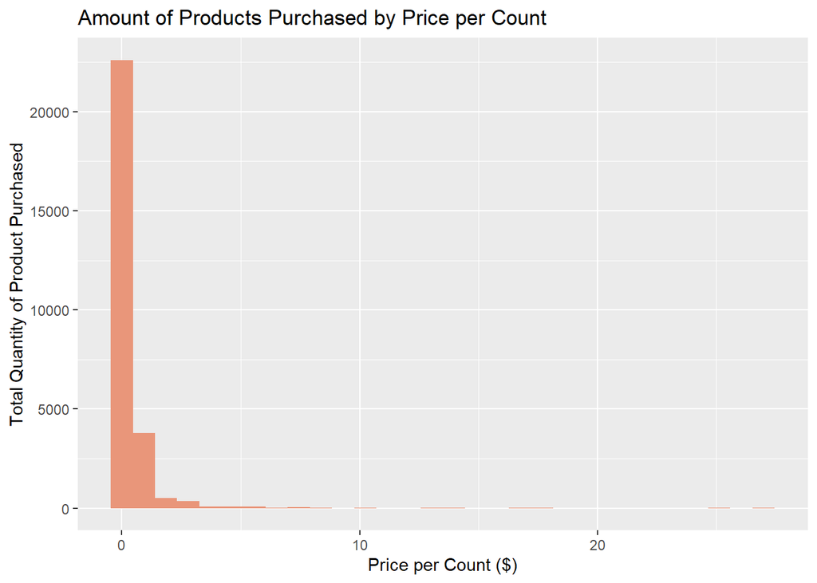

```r
create_unit_histogram(products_ct, unit = ct) +
  labs(title = "Amount of Products Purchased by Price per Count",
       x  = "Price per Count ($)",
       y = "Total Quantity of Product Purchased"
       )
```

This distribution is quite skewed, with most of the purchases being from products with a price per count (ppc) less than $3. Let’s do some analysis to find a price that will give us a better range of prices to look at. We’ll do this by first finding the price per count for each transaction, and then finding an average price per count for each product. Then, we’ll create a boxplot using those numbers. To see the details of the code, look back at the “Establishing Functions” section at the “create_unit_boxplot” function.

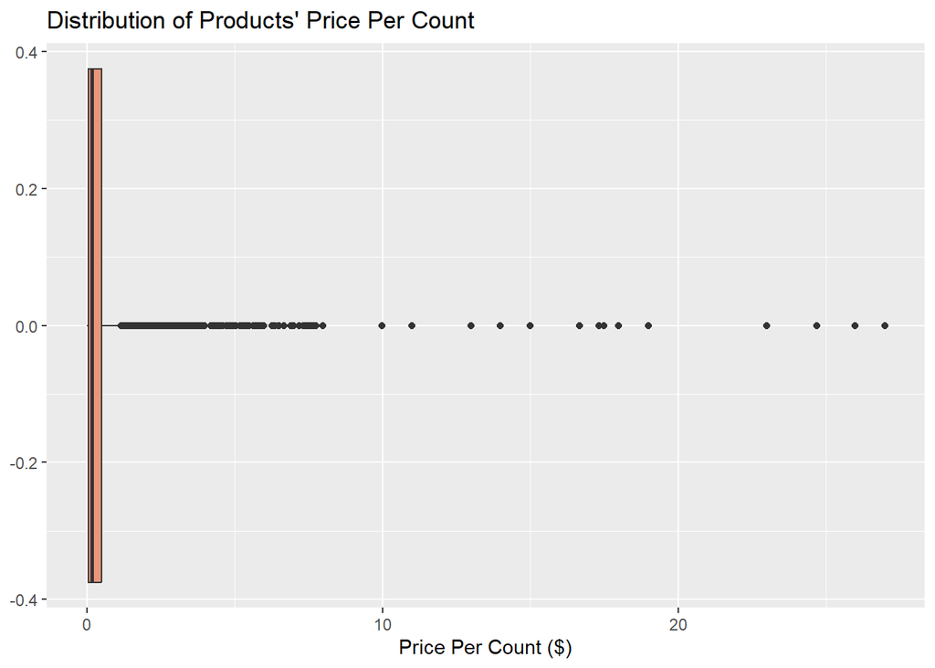

```r
create_unit_boxplot(products_ct, color = "darksalmon") +
  labs(title = "Distribution of Products' Price Per Count",
       x = "Price Per Count ($)")
```

The story this boxplot tells is clearer than that of the histogram. Most of the products, it seems, have a price per count below $1. Let’s get some clear quantile numbers. To see the code for finding quantile numbers, look at the “Establishing Functions” section at the “find_unit_quantiles” function.

```r
find_unit_quantiles(products_ct)
```

```
## # A tibble: 5 × 1
##        quantile
##           <dbl>
## 1  0.0000000361
## 2  0.0653
## 3  0.179
## 4  0.498
## 5 27.0
```

It looks like our third quantile is $0.498, which makes sense with that earlier guess of price per count being below one dollar. Let’s make a new histogram using the third quantile, which will show us a distribution based on 75% of products.

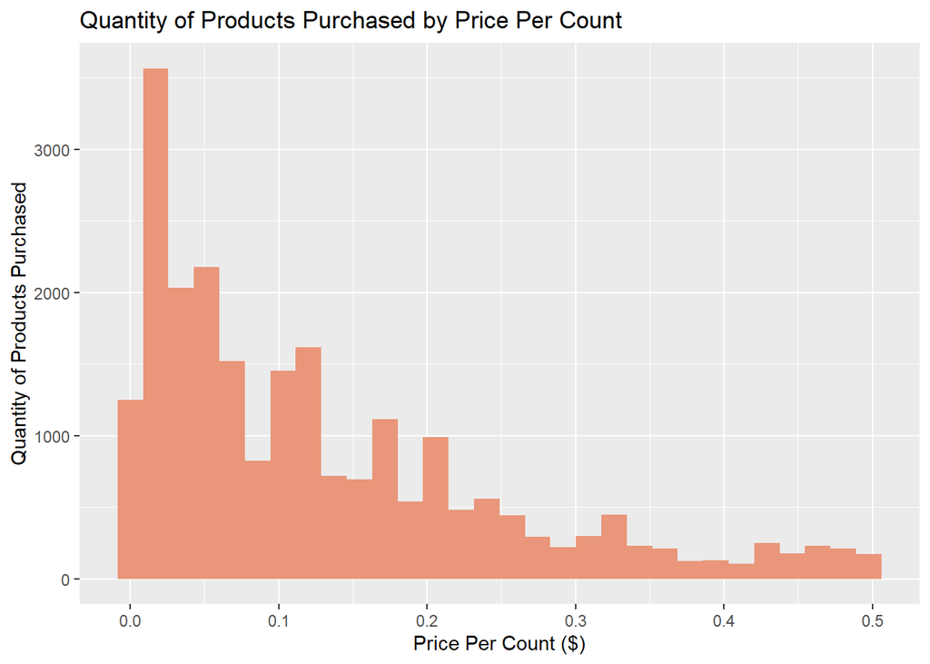

```r
create_unit_histogram(products_ct, "ct", 0.498) +
  labs(title = "Quantity of Products Purchased by Price Per Count",
       x = "Price Per Count ($)",
       y = "Quantity of Products Purchased")
```

Interesting. Even though 75% of products measured by count have a price per count below $0.50, a majority of purchases are way further below that. This indicates that, for products measured by count, people prefer to purchase products with lower prices per count. Let’s see if there’s any differences based on income or household size:

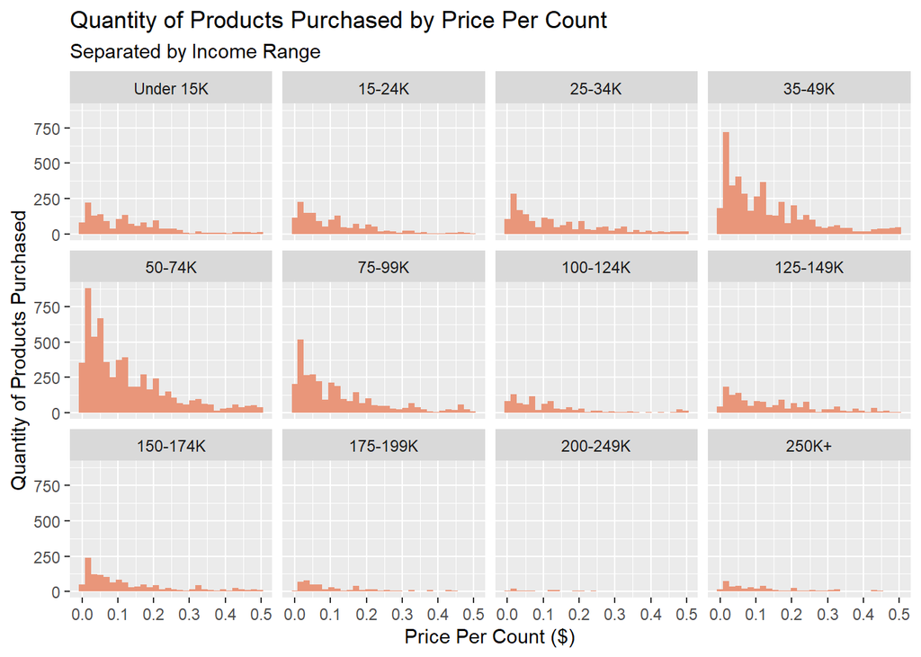

```r
create_unit_histogram(products_ct, "ct", 0.498) +
  labs(title = "Quantity of Products Purchased by Price Per Count",
       subtitle = "Separated by Income Range",
       x = "Price Per Count ($)",
       y = "Quantity of Products Purchased") +
  facet_wrap(~income)
```